# Data Discovery

Pluralsight Data Scientist Take-Home Exercise

Trenton Pulsipher

2019-06-14

## user_assessment_sessions

Below are 100 randomly selected rows from the dataset.

|  | assessment_id | user_id | user_assessment_id | user_assessment_session_id | name | ranking | rd | display_score | percentile | n_questions_answered | date_created | date_modified |
| --- | --- | --- | --- | --- | --- | --- | --- | --- | --- | --- | --- | --- |
| 1 | 37390 | 505 | 680227 | 1091312 | Illustrator | 1269.07 | 132.914 | 157 | 0.546331 | 6 | 2017-06-06T15:20:23Z | 2017-06-06T15:21:45Z |
| 2 | 31638 | 2397651 | 676706 | 1086202 | Python | 931.873 | 78.3418 | 102 | 0.207605 | 19 | 2017-06-04T05:13:45Z | 2017-06-04T05:16:22Z |
| 3 | 31584 | 2414098 | 684166 | 1097037 | Javascript | 1033.21 | 79.8017 | 133 | 0.389159 | 19 | 2017-06-08T15:33:20Z | 2017-06-08T15:41:02Z |
| 4 | 31638 | 2067756 | 676840 | 1086390 | Python | 1211.61 | 350 | 150 | 0.5 | 0 | 2017-06-04T09:54:21Z | 2017-06-04T09:54:21Z |
| 5 | 38414 | 2501372 | 701960 | 1122921 | React | 1538.96 | 78.6201 | 176 | 0.668115 | 20 | 2017-06-20T20:00:35Z | 2017-06-20T20:12:22Z |
| 6 | 31638 | 971333 | 680868 | 1092290 | Python | 1010.32 | 248.163 | 116 | 0.280868 | 1 | 2017-06-06T20:08:12Z | 2017-06-06T20:08:26Z |
| 7 | 31584 | 2513797 | 714170 | 1141072 | Javascript | 908.308 | 125.071 | 72 | 0.0922886 | 7 | 2017-06-28T08:10:37Z | 2017-06-28T08:13:10Z |
| 8 | 31584 | 2504367 | 703228 | 1124833 | Javascript | 1223.16 | 79.1041 | 122 | 0.317807 | 19 | 2017-06-21T14:40:37Z | 2017-06-21T14:49:29Z |
| 9 | 31584 | 751274 | 266691 | 1098834 | Javascript | 1015.94 | 111.204 | 131 | 0.371401 | 9 | 2017-06-09T10:20:40Z | 2017-06-09T10:23:25Z |
| 10 | 31638 | 2266443 | 693145 | 1109940 | Python | 1005.15 | 78.2626 | 86 | 0.139774 | 19 | 2017-06-14T16:41:47Z | 2017-06-14T16:48:29Z |

[output cut: 90 more lines]

### Data Summary

The table below shows several metrics calculated against the various columns/variables. These metrics include: the number of unique values, number of NAs, the maximum value, the minimum value, and the mean/average.

|  | stat | assessment.id | date.created | date.modified | display.score | n.questions.answered | name | percentile | ranking | rd | user.assessment.id | user.assessment.session.id | user.id |
| --- | --- | --- | --- | --- | --- | --- | --- | --- | --- | --- | --- | --- | --- |
| 1 | max | 38414 | 1498780634 | 1504176738 | 287 | 30 | React | 0.994809 | 2233.98 | 350 | 717715 | 1146492 | 2530246 |
| 2 | mean | 33015.4857741839 | 1497562671.74678 | 1497605459.11725 | 127.384696016771 | 15.6936208445642 |  | 0.377201259535789 | 1179.40290266547 | 106.324228541479 | 684900.356843366 | 1112628.43740641 | 1934053.00643905 |
| 3 | min | 31584 | 1496275357 | 1496275357 | 7 | 0 | Illustrator | 0.00242383 | 243.838 | 77.9938 | 115737 | 730235 | 505 |
| 4 | nas | 0 | 0 | 0 | 0 | 0 | 0 | 0 | 0 | 0 | 0 | 0 | 0 |
| 5 | numUnique | 4 | 6670 | 6660 | 254 | 31 | 4 | 6390 | 6271 | 5474 | 6678 | 6678 | 6248 |

### Categorical Variables in Bar Charts

A quick look at counts of the various levels of the categorical variables found in the data is shown in the following set of bar charts. [Trelliscopejs](https://hafen.github.io/trelliscopejs/) is an R package that enables one to quickly sort and/or filter through various slices (or features) of their previously generated visualizations/plots of their data. We can then sort and filter through the feature set to find anomalies or interesting behaviors that might influence modeling or help us understand basic relationships between variables in the data.

For this dataset the number of categorical variables is not overwhelming so the power of trelliscope would appear limited. However, when one needs to quickly move through 100s, 1000s or even millions of slices of the data, trelliscope provides a seemless interface to manage so many subsets of data and better discover interesting features.

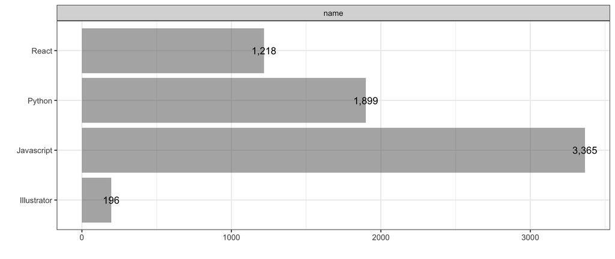

### Numeric Variables in Histograms

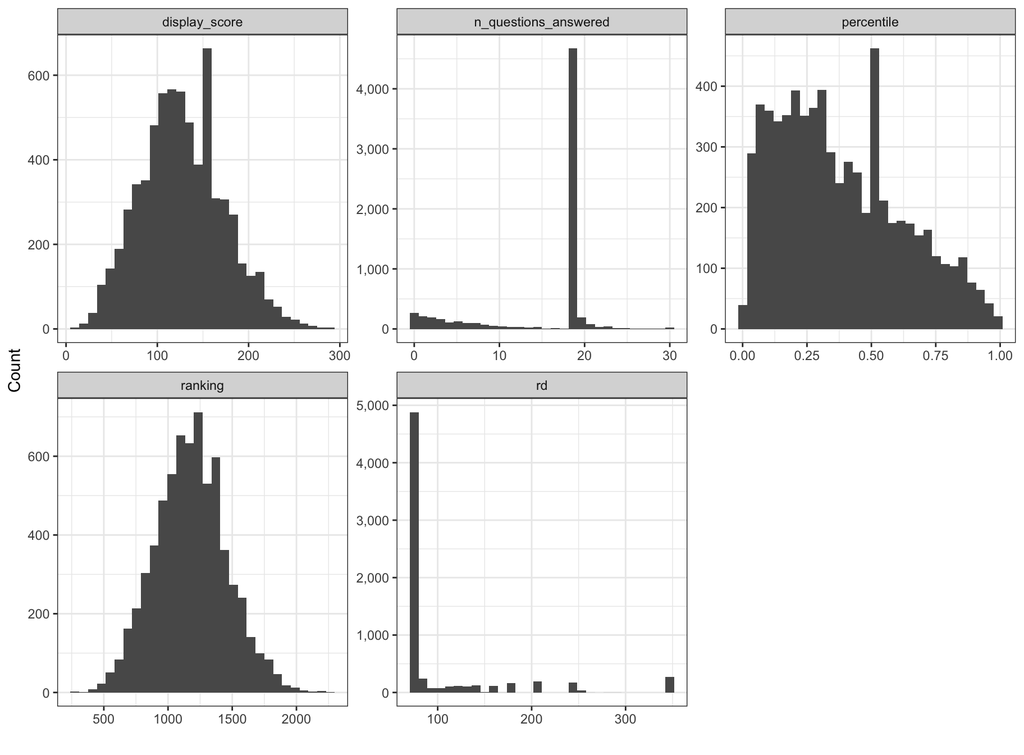

### Time Series Variables

[interactive chart not shown]

# user_interactions

Below are 100 randomly selected rows from the dataset.

|  | user_interaction_id | user_assessment_session_id | assessment_item_id | ranking | rd | display_score | percentile | date_created |
| --- | --- | --- | --- | --- | --- | --- | --- | --- |
| 1 | 13615262 | 1114558 | 163759 | 1670.52 | 133.254 | 193 | 0.765048 | 2017-06-16T13:29:54Z |
| 2 | 13338883 | 1092693 | 170288 | 1373.7 | 124.279 | 178 | 0.683932 | 2017-06-06T22:45:45Z |
| 3 | 13487498 | 1104243 | 170467 | 1640.18 | 80.6181 | 224 | 0.897566 | 2017-06-12T15:49:49Z |
| 4 | 13460212 | 1102108 | 163936 | 919.691 | 116.888 | 114 | 0.272885 | 2017-06-11T12:53:27Z |
| 5 | 13780967 | 1127816 | 166718 | 1304.17 | 78.7799 | 135 | 0.398549 | 2017-06-22T14:01:02Z |
| 6 | 13987403 | 1144382 | 163868 | 1165.18 | 97.4002 | 112 | 0.262816 | 2017-06-29T11:11:04Z |
| 7 | 13998366 | 1145320 | 163920 | 1153.66 | 132.429 | 110 | 0.252046 | 2017-06-29T16:51:53Z |
| 8 | 13287455 | 1088747 | 163758 | 1190.01 | 132.686 | 159 | 0.562956 | 2017-06-05T15:59:23Z |
| 9 | 13448072 | 1101122 | 264266 | 1193.54 | 93.5886 | 141 | 0.442762 | 2017-06-10T15:12:10Z |
| 10 | 13725821 | 1123510 | 163859 | 799.089 | 85.4443 | 56 | 0.053882 | 2017-06-21T02:53:16Z |

[output cut: 90 more lines]

### Data Summary

|  | stat | assessment.item.id | date.created | display.score | percentile | ranking | rd | user.assessment.session.id | user.interaction.id |
| --- | --- | --- | --- | --- | --- | --- | --- | --- | --- |
| 1 | max | 266098 | 1498849408 | 288 | 0.99549 | 2233.98 | 276.41 | 1146492 | 14040346 |
| 2 | mean | 184283.178905566 | 1497562179.24795 | 134.700554813027 | 0.415293463054164 | 1221.19269994904 | 124.891091885499 | 1112472.03523111 | 13590487.2761277 |
| 3 | min | 163730 | 1496275552 | 7 | 0.00242383 | 243.838 | 77.9938 | 730235 | 13176684 |
| 4 | nas | 0 | 0 | 0 | 0 | 0 | 0 | 0 | 0 |
| 5 | numUnique | 727 | 101327 | 281 | 98169 | 70689 | 54136 | 6394 | 103999 |

### Numeric Variables in Histograms

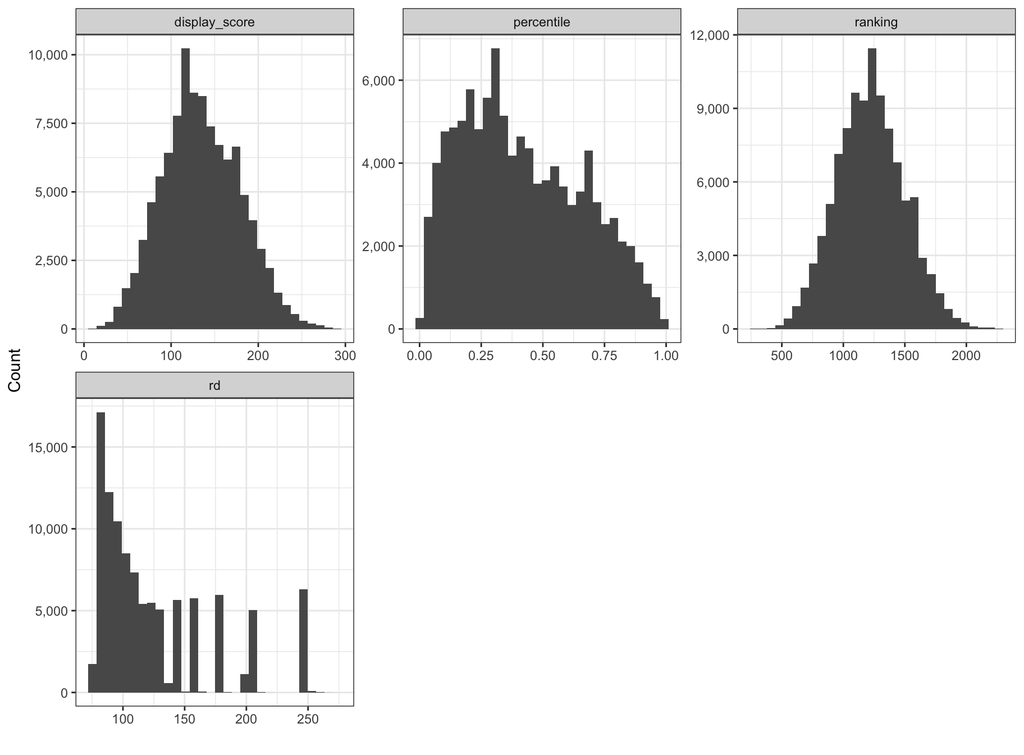

### Time Series Variables

[interactive chart not shown]

# question_details

Below are 100 randomly selected rows from the dataset.

|  | assessment_id | item_content_id | topic_name | date_created |
| --- | --- | --- | --- | --- |
| 1 | 31638 | 432437 | Objects | 2015-09-16T09:06:49Z |
| 2 | 31638 | 347092 | Scalars &amp; Operators | 2015-09-16T11:34:31Z |
| 3 | 31584 | 323215 | Operators | 2015-07-03T00:16:03Z |
| 4 | 31584 | 324622 | Basics | 2015-07-06T18:53:13Z |
| 5 | 38414 | 525898 | Components | 2016-12-12T02:01:53Z |
| 6 | 31638 | 432386 | Objects | 2015-09-15T11:43:07Z |
| 7 | 31584 | 330264 | Types | 2015-07-03T00:16:09Z |
| 8 | 37390 | 485270 | Drawing and Painting | 2016-05-11T20:53:05Z |
| 9 | 38414 | 522105 | State | 2016-11-22T02:07:52Z |
| 10 | 31584 | 493803 | Types | 2015-07-03T00:16:06Z |

[output cut: 90 more lines]

### Data Summary

|  | stat | assessment.id | date.created | item.content.id | topic.name |
| --- | --- | --- | --- | --- | --- |
| 1 | max | 38414 | 1483477579 | 559179 | Working with Placed Graphics |
| 2 | mean | 33901.9096573209 | 1450502441.02492 | 468875.746105919 |  |
| 3 | min | 31584 | 1435882560 | 323148 | Arrays |
| 4 | nas | 0 | 0 | 0 | 0 |
| 5 | numUnique | 4 | 437 | 642 | 35 |

### Categorical Variables in Bar Charts

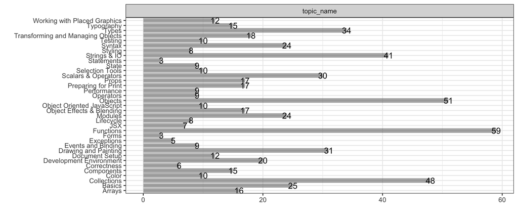

### Time Series Variables

[interactive chart not shown]

# question_interactions

Below are 100 randomly selected rows from the dataset.

|  | user_interaction_id | user_assessment_session_id | assessment_item_id | item_content_id | result | ranking | rd | date_created | client_elapsed_time |
| --- | --- | --- | --- | --- | --- | --- | --- | --- | --- |
| 1 | 13943549 | 1140800 | 163859 | 328242 | Correct | 948.658 | 30 | 2017-06-28T05:18:05Z | 20944 |
| 2 | 13920924 | 1139022 | 264359 | 527099 | Incorrect | 856.832 | 30 | 2017-06-27T15:03:10Z | 33447 |
| 3 | 13817040 | 1130717 | 264488 | 525455 | Correct | 1323.04 | 30 | 2017-06-23T14:20:00Z | 25702 |
| 4 | 13292833 | 1089186 | 163758 | 492656 | Incorrect | 1100.94 | 30 | 2017-06-05T18:45:43Z | 50162 |
| 5 | 13191802 | 1081196 | 163936 | 1212 | Correct | 1008.54 | 30 | 2017-06-01T13:41:08Z | 8175 |
| 6 | 13746723 | 1125169 | 264347 | 525255 | Incorrect | 1369.2 | 30 | 2017-06-21T16:51:00Z | 9618 |
| 7 | 13786554 | 1128297 | 170293 | 490145 | Correct | 1398.56 | 30 | 2017-06-22T16:44:41Z | 20547 |
| 8 | 13854088 | 1133664 | 170340 | 490173 | Correct | 1118.54 | 30 | 2017-06-25T07:05:32Z | -225089 |
| 9 | 13731403 | 1123945 | 170529 | 4844 | Correct | 1389.57 | 30 | 2017-06-21T08:39:13Z | 10227 |
| 10 | 13300212 | 1089754 | 170494 | 490147 | Incorrect | 1166.88 | 30 | 2017-06-05T22:22:32Z | 10300 |

[output cut: 90 more lines]

### Data Summary

|  | stat | assessment.item.id | client.elapsed.time | date.created | item.content.id | ranking | rd | result | user.assessment.session.id | user.interaction.id |
| --- | --- | --- | --- | --- | --- | --- | --- | --- | --- | --- |
| 1 | max | 266098 | 1791147521 | 1498849386 | 558905 | 2385.77 | 262.931 | Timed Out | 1146492 | 14040346 |
| 2 | mean | 184281.182383768 | 472654.311341891 | 1497561803.6166 | 304451.732814078 | 1222.81394851676 | 31.3812480378864 |  | 1112472.88817732 | 13590497.6317611 |
| 3 | min | 163730 | -58714761 | 1496275530 | 1007 | 261.844 | 30 | Correct | 730235 | 13176684 |
| 4 | nas | 0 | 0 | 0 | 0 | 0 | 0 | 0 | 0 | 0 |
| 5 | numUnique | 724 | 41797 | 101339 | 871 | 68382 | 2167 | 3 | 6394 | 103995 |

### Categorical Variables in Bar Charts

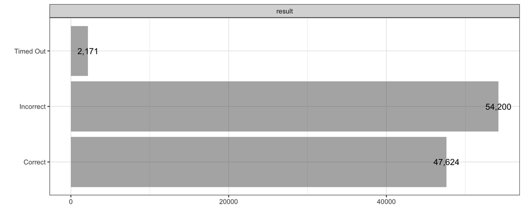

### Numeric Variables in Histograms

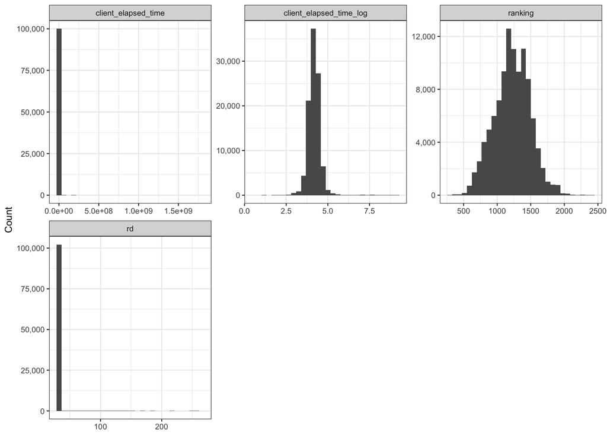

### Time Series Variables

[interactive chart not shown]